# GLR_ClassificationProject_Milestone#2

Kendall Leonard

2023-03-17

```r
library(tidyverse)
dino<-read_csv("https://raw.githubusercontent.com/k-leonard/dino/main/data.csv")
weight<-read_csv("https://raw.githubusercontent.com/k-leonard/dino/main/Jurassic%20Park%20Extended%20Edition%20-%20Sheet1%20(4).csv")
dino <- merge(x=dino,y=weight,
             by="name", all.x=TRUE)
```

### MERGING WITH CENTROIDS OF COUNTRIES

```r
dino$COUNTRY <- dino$lived_in

dino<-dino%>%
  mutate(COUNTRY=str_replace(COUNTRY, "USA", "United States"))

dino<-dino%>%
  mutate(COUNTRY=str_replace(COUNTRY, "Wales", "United Kingdom"))

dino<-dino%>%
  mutate(COUNTRY=str_replace(COUNTRY, "Russia", "Russian Federation"))
```

```r
centroids <- read.csv("https://raw.githubusercontent.com/gavinr/world-countries-centroids/master/dist/countries.csv")
#View(centroids)
```

```r
dino <- merge(x=dino,y=centroids,
             by="COUNTRY", all.x=TRUE)
str(dino)
```

```
## 'data.frame':    309 obs. of  19 variables:
##  $ COUNTRY   : chr  "Antarctica" "Argentina" "Argentina" "Argentina" ...
##  $ name      : chr  "cryolophosaurus" "eoraptor" "herrerasaurus" "abelisaurus" ...
##  $ diet      : chr  "carnivorous" "carnivorous" "carnivorous" "carnivorous" ...
##  $ period    : chr  "Early Jurassic 170 million years ago" "Late Triassic 228 million years ago" "Late Triassic 228 million years ago" "Late Cretaceous 74-70 million years ago" ...
##  $ lived_in  : chr  "Antarctica" "Argentina" "Argentina" "Argentina" ...
##  $ type      : chr  "large theropod" "small theropod" "small theropod" "large theropod" ...
##  $ length    : chr  "8.0m" "1.0m" "3.0m" "9.0m" ...
##  $ taxonomy  : chr  "Dinosauria Saurischia Theropoda Neotheropoda Tetanurae Avetheropoda Carnosauria" "Dinosauria Saurischia Theropoda" "Dinosauria Saurischia Theropoda Herrerasauridae" "Dinosauria Saurischia Theropoda Neotheropoda Ceratosauria Neoceratosauria Abelisauridae Abelisaurinae" ...
##  $ named_by  : chr  "Hammer and Hickerson (1994)" "Sereno Forster Rogers and Monetta (1993)" "Reig (1963)" "Bonaparte and Novas (1985)" ...
##  $ species   : chr  "elliotti" "lunensis" "ischigualastensis" "comahuensis" ...
##  $ link      : chr  "https://www.nhm.ac.uk/discover/dino-directory/cryolophosaurus.html" "https://www.nhm.ac.uk/discover/dino-directory/eoraptor.html" "https://www.nhm.ac.uk/discover/dino-directory/herrerasaurus.html" "https://www.nhm.ac.uk/discover/dino-directory/abelisaurus.html" ...
##  $ weight    : chr  "350–465 kilograms" "5–10 kilograms" "350 kg" "3 tons" ...
##  $ weightkg  : chr  "407.5 kg" "7.5 kg" "350 kg" "3000 kg" ...
##  $ num_of_ped: chr  "2" "2" "2" "2" ...
##  $ longitude : num  -177.6 -64.5 -64.5 -64.5 -64.5 ...
##  $ latitude  : num  -77.2 -35.7 -35.7 -35.7 -35.7 ...
##  $ ISO       : chr  "AQ" "AR" "AR" "AR" ...
##  $ COUNTRYAFF: chr  "Antarctica" "Argentina" "Argentina" "Argentina" ...
##  $ AFF_ISO   : chr  "AQ" "AR" "AR" "AR" ...
```

```r
sum(is.na(dino))
```

```
## [1] 35
```

```r
dino[129,3]<-"carnivorous" #fixing a data mistake
dino[153,3]<-"herbivorous"
dino[7,3]<-"herbivorous"

dino[309,1]<-"USA"
dino[309,4]<-"Late Cretaceous"
dino[309,5]<-"USA"


dino<-na.omit(dino)
```

#Datacleaning/Wrangling A summary: Everything in this dataset is a character, which means that there will be a lot of transformations.

First the length and weight need to be split from their units, and after double checking that all are in the same units, transform them into numbers with the unit in the column name.

During this exploration and transformation, we discovered a strange issue, most likely with the original data collection, where the type of dinosaur was skipped and in its place was the length. It was during this that we discovered 17 na’s in length alone, so that might have to be supplemented with outside data if we need more rows.

After that, if we want to check to see if location plays a part, we need location to be a indicator This of course can be reversed at any point.

We also need to change the diet column to be an indicator as well, as we cannot predict strings.

We also plan to split taxonomy, to see if any of those features are connected to the diet of the dinosaur.

It might be interesting to see if species are grouped together, but there are so many unique ones they are most likely not connect. Might be a furture avenue if needed.

I think time period would also be interesting to explore.

###Suplementing the data ####Adding in weights We will be supplementing more data, so this is just the beginning.

###Turning Characters into Numbers

```r
length<-as.numeric(str_remove(dino$length,"m"))
dino$length_in_m<-length
```

Will be turning new columns into numbers as well

```r
weights<-as.numeric(str_remove(dino$weightkg,"kg"))

dino$weights_in_kg<-weights
```

##Turning Diet Into a Factor

```r
dino<-dino%>%
  mutate(diet=str_replace(diet, "omnivorous", "carnivorous"))
```

```r
uniDiet<-unique(dino$diet)
dietDat<-matrix(0, nrow=284, ncol=length(uniDiet))
colnames(dietDat)<-uniDiet

for(i in 1:284){
  for(j in 1:length(uniDiet)){
    if(colnames(dietDat)[j] %in% str_split(dino$diet[i]," ", simplify = TRUE)){
      dietDat[i, j]=1
    }
  }
}
dino<-dino%>%
  cbind(dietDat)
```

##Turning num_peds Into a Factor

```r
unifeet<-unique(dino$num_of_ped)
feetDat<-matrix(0, nrow=284, ncol=2)
colnames(feetDat)<-c("Two", "Four")

for(i in 1:284){
  if(dino$num_of_ped[i]=="2"){
    feetDat[i, 1]=1
  }

    if(dino$num_of_ped[i]=="4"){
    feetDat[i, 2]=1
  }

    if(dino$num_of_ped[i]=="both"){
      feetDat[i, 1]=1
      feetDat[i, 2]=1
    }
}
dino<-dino%>%
  cbind(feetDat)
```

##Turning period Into a BINARY Factor Will Continue working on this

```r
guess<-as.data.frame(str_split(dino$period, " ", simplify = TRUE))
time_period<-subset(guess, select=c("V1","V2"))
dino$time_period<-paste(time_period$V1, "", time_period$V2)
dino$time_period<-str_remove(dino$time_period," ")

UniqueTime<-unique(dino$time_period)
TimeData<-matrix(0, nrow=284, ncol= length(UniqueTime))
colnames(TimeData)<-UniqueTime

for (i in 1:284){
  for (j in 1:length(UniqueTime)){
    if(colnames(TimeData)[j] == dino$time_period[i]){
      TimeData[i, j]= 1
    }
  }
}

dino<-dino%>%
  cbind(TimeData)
```

# Questions of Interest:

Can the length of the dinosaur in meters (length) accurately predict the diet of a dinosaur?

```
Variables: diet, length
```

Which predictor results in the least amount of false positives when predicting the type of dinosaur?

```
variables:
```

Is the place where the dinosaur lived (lived_in) or the time period when they lived (period) a better predictor of type of dinosaur?

```
Variables: period, lived_in, type
```

#MILESTONE 2

```r
names(dino)[c(14,15,16,20,21,27,28,29,30,31,32)]
```

```
##  [1] "num_of_ped"       "longitude"        "latitude"         "length_in_m"
##  [5] "weights_in_kg"    "Early Jurassic"   "Late Triassic"    "Late Cretaceous"
##  [9] "Mid Jurassic"     "Early Cretaceous" "Late Jurassic"
```

##Step 0

```r
library(GGally)
```

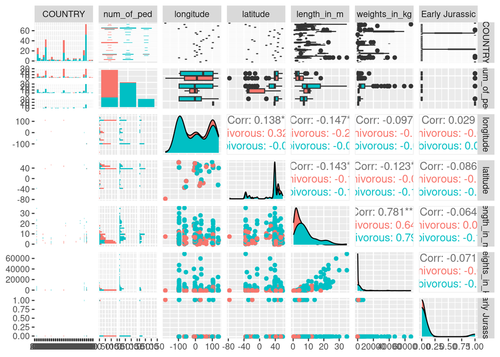

```r
ggpairs(dino, columns=c(1,14,15,16,20,21,27),cardinality_threshold = 32, ggplot2::aes(colour = diet))
```

### STEP 2

```r
## PARTITION DATA
dinoVeggie<-dino%>%
  filter(carnivorous==0)
dim(dinoVeggie)
```

```
## [1] 168  32
```

```r
dinoMeat<-dino%>%
  filter(carnivorous==1)
dim(dinoMeat)
```

```
## [1] 116  32
```

```r
## SAMPLE INDECES
sample0<-sample(1:168, 118)
sample1<-sample(1:116, 81)

## TRAINING AND TESTING SETS
trainStrat<-rbind(dinoVeggie[sample0, ],
                  dinoMeat[sample1, ])

testStrat<-rbind(dinoVeggie[-sample0, ],
                  dinoMeat[-sample1, ])

## PROPORITON OF OUTCOME
mean(trainStrat$carnivorous)
```

```
## [1] 0.4070352
```

```r
mean(testStrat$carnivorous)
```

```
## [1] 0.4117647
```

```r
trainStrat$carnivorous <- as.numeric(as.factor(trainStrat$carnivorous))
testStrat$carnivorous <- as.numeric(as.factor(testStrat$carnivorous))
```

###Caret

```r
library(caret)
# Split the data into training and test set
set.seed(314)
caretSamp <- createDataPartition(dino$carnivorous ,
                                        p = 0.55, #This amount gets us the most equal proportions
                                        list = FALSE)

## SPLIT TESTING AND TRAINING
trainCaret  <- dino[caretSamp, ]%>%
  select(c(15,16,20,21,22,23,24,25,27,28,29,30,31,32))

str(trainCaret)
```

```
## 'data.frame':    157 obs. of  14 variables:
##  $ longitude       : num  -177.6 -64.5 -64.5 -64.5 -64.5 ...
##  $ latitude        : num  -77.2 -35.7 -35.7 -35.7 -35.7 ...
##  $ length_in_m     : num  8 1 5.15 10 24 10 15 1 12.5 23 ...
##  $ weights_in_kg   : num  407.5 7.5 800 5000 7000 ...
##  $ carnivorous     : num  1 1 0 0 0 0 0 1 1 0 ...
##  $ herbivorous     : num  0 0 1 1 1 1 1 0 0 1 ...
##  $ Two             : num  1 1 0 0 0 0 0 1 1 0 ...
##  $ Four            : num  0 0 1 1 1 1 1 0 0 1 ...
##  $ Early Jurassic  : num  1 0 0 0 0 0 0 0 0 0 ...
##  $ Late Triassic   : num  0 1 1 0 0 0 0 0 0 0 ...
##  $ Late Cretaceous : num  0 0 0 0 0 1 0 1 0 0 ...
##  $ Mid Jurassic    : num  0 0 0 1 0 0 1 0 0 0 ...
##  $ Early Cretaceous: num  0 0 0 0 1 0 0 0 1 1 ...
##  $ Late Jurassic   : num  0 0 0 0 0 0 0 0 0 0 ...
```

```r
testCaret <- dino%>%
  select(c(15,16,20,21,22,23,24,25,27,28,29,30,31,32))


## PROPORITON OF OUTCOME
mean(trainCaret$carnivorous)
```

```
## [1] 0.4076433
```

```r
mean(testCaret$carnivorous)
```

```
## [1] 0.4084507
```

### STEP 3

```r
library(class)
trainFea<-trainCaret%>%
  select(-c(carnivorous))
dim(trainFea)
```

```
## [1] 157  13
```

```r
testFea<-testCaret%>%
  select(-c(carnivorous))
dim(testFea)
```

```
## [1] 284  13
```

```r
trainOut<-trainCaret$carnivorous
testOut<-testCaret$carnivorous
sum(is.na(trainFea))
```

```
## [1] 0
```

```r
sum(is.na(testFea))
```

```
## [1] 0
```

```r
sum(is.na(trainOut))
```

```
## [1] 0
```

```r
set.seed(72)

knn.pred=knn(train = trainFea,
             test = testFea,
             cl = trainOut,
             k=3)

head(knn.pred)
```

```
## [1] 0 1 1 0 1 1
## Levels: 0 1
```

### STEP 4

### STEP 4A

```r
#Confusion matrix
cm<-table(knn.pred,testOut)
cm
```

```
##         testOut
## knn.pred   0   1
##        0 128  27
##        1  40  89
```

### STEP 4B

```r
#correct rate

mean(knn.pred==testOut)
```

```
## [1] 0.7640845
```

### STEP 4C

```r
#error rate

mean(knn.pred!=testOut)
```

```
## [1] 0.2359155
```

### STEP 4D

```r
#false positive rate

40/(40+128)
```

```
## [1] 0.2380952
```

### STEP 4E

```r
#false negative rate

27/(27+89)
```

```
## [1] 0.2327586
```

### STEP 4F

```r
#sensitivity
#Sensitivity = True Positive / (True Positive + False Negative)
89/(89+27)
```

```
## [1] 0.7672414
```

### STEP 4G

```r
#specificity
#Specificity = True Negative / (False Positive + True Negative)

128/(40+128)
```

```
## [1] 0.7619048
```

### STEP 5

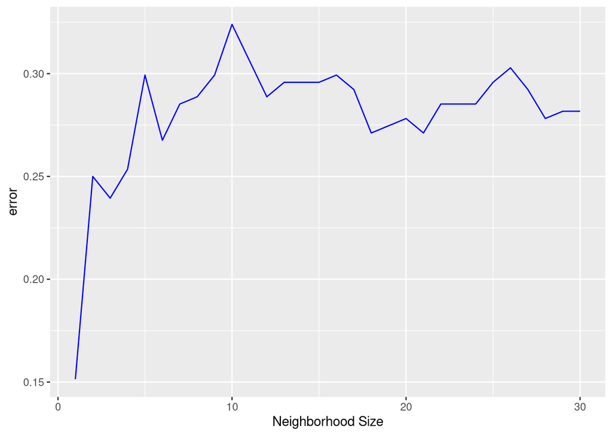

```r
set.seed(123)
error <- c()
for (i in 1:30){
  knnDino<- knn(train = trainFea,
                test = testFea,
                cl = trainOut,
                k = i)
  error[i] = 1- mean(knnDino==testOut)
}


ggplot(data = data.frame(error), aes(x = 1:30, y = error)) +
  geom_line(color = "Blue")+
  xlab("Neighborhood Size")
```

```r
#The best knn model uses only one neighbor!
which.min(error)
```

```
## [1] 1
```

```r
min(error)
```

```
## [1] 0.1514085
```

### STEP 6

```r
knn.best=knn(train = trainFea,
             test = testFea,
             cl = trainOut,
             k=1)
```

### STEP 6A

```r
#confusion matrix
conf<-table(knn.best,testOut)
conf
```

```
##         testOut
## knn.best   0   1
##        0 143  18
##        1  25  98
```

### STEP 6B

```r
#correct rate

mean(knn.best==testOut)
```

```
## [1] 0.8485915
```

### STEP 6C

```r
#error rate

mean(knn.best!=testOut)
```

```
## [1] 0.1514085
```

### STEP 6D

```r
#false positive rate
#FP/FP+TN
25/(25+143)
```

```
## [1] 0.1488095
```

### STEP 6E

```r
#false negative rate
#FN/FN+TN
18/(18+143)
```

```
## [1] 0.1118012
```

### STEP 6F

```r
#sensitivity
#Sensitivity = True Positive / (True Positive + False Negative)
98/(98+18)
```

```
## [1] 0.8448276
```

### STEP 6G

```r
#specificity
#Specificity = True Negative / (False Positive + True Negative)

143/(143+25)
```

```
## [1] 0.8511905
```

### STEP 6 (Caret)

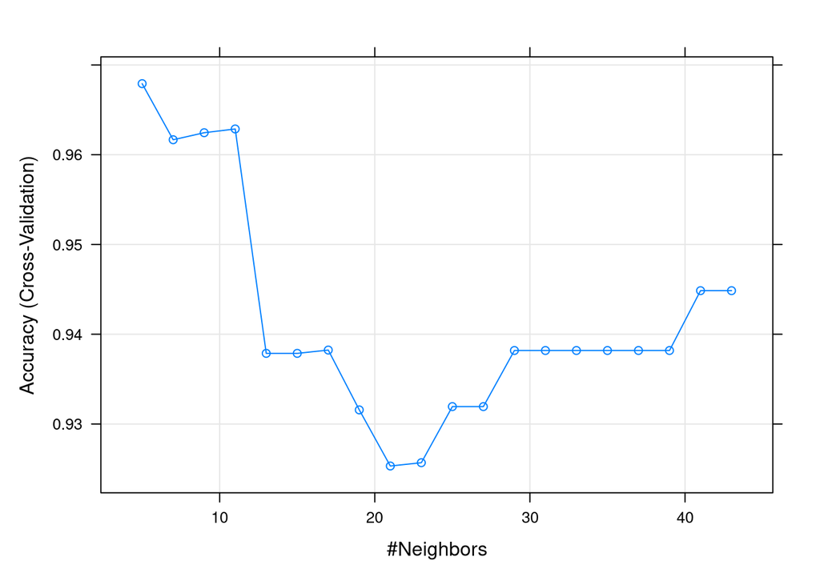

```r
### THE CARET METHOD CARET
set.seed(314)
model <- train(
  factor(carnivorous) ~.,
  data = trainCaret ,
  method = "knn",
  trControl = trainControl("cv", number = 10),
  preProcess = c("range"),
  tuneLength = 20
)
# Plot model accuracy vs different values of k
plot(model)
```

### PART 3

### Step 7

```r
dinomod<-glm(carnivorous~weights_in_kg, data=dino, family="binomial")
summary(dinomod)
```

```
##
## Call:
## glm(formula = carnivorous ~ weights_in_kg, family = "binomial",
##     data = dino)
##
## Deviance Residuals:
##     Min       1Q   Median       3Q      Max
## -1.3388  -0.9974  -0.2676   1.0318   2.5763
##
## Coefficients:
##                 Estimate Std. Error z value Pr(>|z|)
## (Intercept)    3.729e-01  1.642e-01   2.271   0.0231 *
## weights_in_kg -4.061e-04  8.087e-05  -5.022 5.12e-07 ***
## ---
## Signif. codes:  0 '***' 0.001 '**' 0.01 '*' 0.05 '.' 0.1 ' ' 1
##
## (Dispersion parameter for binomial family taken to be 1)
##
##     Null deviance: 384.13  on 283  degrees of freedom
## Residual deviance: 324.21  on 282  degrees of freedom
## AIC: 328.21
##
## Number of Fisher Scoring iterations: 7
```

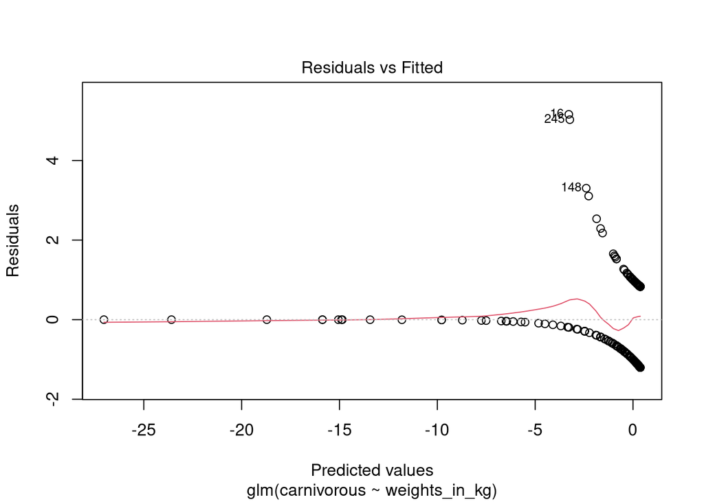

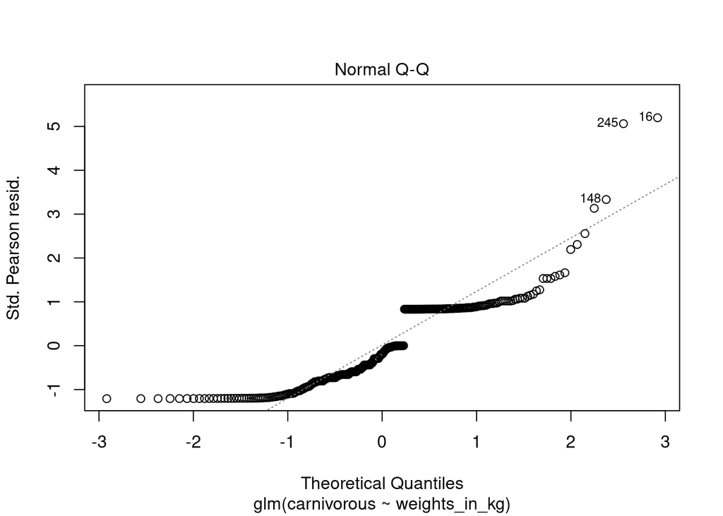

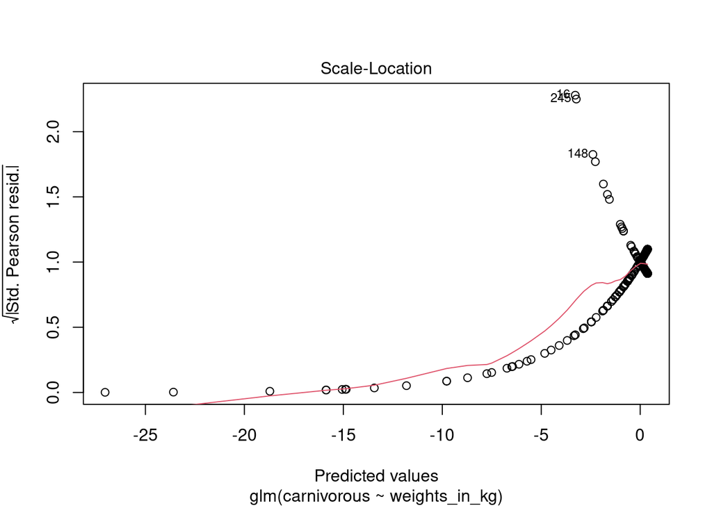

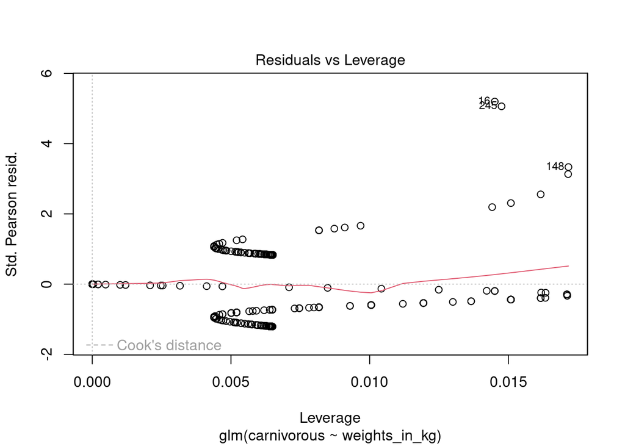

```r
plot(dinomod)
```

### STEP 8 ###

### STEP 9

```r
### PREDICT
dino_prob <- predict(dinomod, testFea, type = "response")
head(dino_prob)
```

```
##         1         2         3         4         5         6
## 0.5516691 0.5914224 0.5574369 0.3004102 0.5908826 0.5221451
```

```r
## THRESHOLD

dino_pred<-ifelse(dino_prob>.5, "carnivorous", "herbivorous")
```

```r
###  CONFUSION MATRIX
table(dino_pred, testFea$herbivorous)
```

```
##
## dino_pred       0   1
##   carnivorous  86  56
##   herbivorous  30 112
```

```r
## CORRECT RATE
mean(dino_pred == testFea$herbivorous)
```

```
## [1] 0
```

### STEP 10

```r
fulldino<-glm(carnivorous~weights_in_kg+length_in_m+Two+Four+longitude+latitude+`Early Jurassic`+`Late Triassic`+`Late Cretaceous`+`Mid Jurassic`+`Early Cretaceous`+`Late Jurassic`, data=dino, family="binomial")
summary(fulldino)
```

```
##
## Call:
## glm(formula = carnivorous ~ weights_in_kg + length_in_m + Two +
##     Four + longitude + latitude + `Early Jurassic` + `Late Triassic` +
##     `Late Cretaceous` + `Mid Jurassic` + `Early Cretaceous` +
##     `Late Jurassic`, family = "binomial", data = dino)
##
## Deviance Residuals:
##     Min       1Q   Median       3Q      Max
## -2.1549  -0.2642  -0.1134   0.6762   2.6208
##
## Coefficients: (1 not defined because of singularities)
##                      Estimate Std. Error z value Pr(>|z|)
## (Intercept)        -0.0824164  1.4111669  -0.058  0.95343
## weights_in_kg      -0.0003878  0.0001375  -2.821  0.00479 **
## length_in_m         0.2573219  0.0826908   3.112  0.00186 **
## Two                 0.3946573  1.2595638   0.313  0.75403
## Four               -4.7627042  1.0649689  -4.472 7.74e-06 ***
## longitude           0.0004648  0.0022758   0.204  0.83817
## latitude           -0.0033353  0.0068548  -0.487  0.62657
## `Early Jurassic`   -0.3830413  0.9401966  -0.407  0.68371
## `Late Triassic`     0.9732684  0.9826258   0.990  0.32194
## `Late Cretaceous`   0.1809960  0.5690877   0.318  0.75045
## `Mid Jurassic`      0.1741569  0.8134590   0.214  0.83047
## `Early Cretaceous`  0.2160664  0.6440801   0.335  0.73727
## `Late Jurassic`            NA         NA      NA       NA
## ---
## Signif. codes:  0 '***' 0.001 '**' 0.01 '*' 0.05 '.' 0.1 ' ' 1
##
## (Dispersion parameter for binomial family taken to be 1)
##
##     Null deviance: 384.13  on 283  degrees of freedom
## Residual deviance: 190.88  on 272  degrees of freedom
## AIC: 214.88
##
## Number of Fisher Scoring iterations: 7
```

### STEP 11

```r
library(bestglm)
step(fulldino)
```

```
## Start:  AIC=214.88
## carnivorous ~ weights_in_kg + length_in_m + Two + Four + longitude +
##     latitude + `Early Jurassic` + `Late Triassic` + `Late Cretaceous` +
##     `Mid Jurassic` + `Early Cretaceous` + `Late Jurassic`
##
##
## Step:  AIC=214.88
## carnivorous ~ weights_in_kg + length_in_m + Two + Four + longitude +
##     latitude + `Early Jurassic` + `Late Triassic` + `Late Cretaceous` +
##     `Mid Jurassic` + `Early Cretaceous`
##
##                      Df Deviance    AIC
## - longitude           1   190.93 212.93
## - `Mid Jurassic`      1   190.93 212.93
## - Two                 1   190.98 212.98
## - `Late Cretaceous`   1   190.99 212.99
## - `Early Cretaceous`  1   191.00 213.00
## - `Early Jurassic`    1   191.05 213.05
## - latitude            1   191.12 213.12
## - `Late Triassic`     1   191.93 213.93
## <none>                    190.88 214.88
## - length_in_m         1   201.82 223.82
## - weights_in_kg       1   202.14 224.14
## - Four                1   248.68 270.68
##
## Step:  AIC=212.93
## carnivorous ~ weights_in_kg + length_in_m + Two + Four + latitude +
##     `Early Jurassic` + `Late Triassic` + `Late Cretaceous` +
##     `Mid Jurassic` + `Early Cretaceous`
##
##                      Df Deviance    AIC
## - `Mid Jurassic`      1   190.99 210.99
## - Two                 1   191.01 211.01
## - `Late Cretaceous`   1   191.05 211.05
## - `Early Jurassic`    1   191.07 211.07
## - `Early Cretaceous`  1   191.08 211.08
## - latitude            1   191.13 211.13
## - `Late Triassic`     1   191.98 211.98
## <none>                    190.93 212.93
## - length_in_m         1   201.98 221.98
```

[output cut: 37 more lines]

```
##     `Early Jurassic` + `Late Triassic`
##
##                    Df Deviance    AIC
## - Two               1   191.18 205.18
## - latitude          1   191.33 205.33
## - `Early Jurassic`  1   191.51 205.51
## - `Late Triassic`   1   192.01 206.01
## <none>                  191.09 207.09
## - length_in_m       1   202.17 216.17
## - weights_in_kg     1   202.43 216.43
## - Four              1   250.62 264.62
##
## Step:  AIC=205.18
## carnivorous ~ weights_in_kg + length_in_m + Four + latitude +
##     `Early Jurassic` + `Late Triassic`
```

```
##                    Df Deviance    AIC
## - latitude          1   191.41 203.41
## - `Early Jurassic`  1   191.56 203.56
## - `Late Triassic`   1   192.09 204.09
## <none>                  191.18 205.18
## - length_in_m       1   202.18 214.18
## - weights_in_kg     1   202.57 214.57
## - Four              1   319.30 331.30
##
## Step:  AIC=203.41
## carnivorous ~ weights_in_kg + length_in_m + Four + `Early Jurassic` +
##     `Late Triassic`
```

```
##                    Df Deviance    AIC
## - `Early Jurassic`  1   191.76 201.76
## - `Late Triassic`   1   192.64 202.64
## <none>                  191.41 203.41
## - length_in_m       1   202.89 212.89
## - weights_in_kg     1   202.92 212.92
## - Four              1   319.72 329.72
##
## Step:  AIC=201.76
## carnivorous ~ weights_in_kg + length_in_m + Four + `Late Triassic`
```

```
##                   Df Deviance    AIC
## - `Late Triassic`  1   193.07 201.07
## <none>                 191.76 201.76
## - length_in_m      1   203.07 211.07
## - weights_in_kg    1   203.07 211.07
## - Four             1   322.59 330.59
##
## Step:  AIC=201.07
## carnivorous ~ weights_in_kg + length_in_m + Four
```

```
##                 Df Deviance    AIC
## <none>               193.07 201.07
## - length_in_m    1   204.05 210.05
## - weights_in_kg  1   204.51 210.51
## - Four           1   323.21 329.21
```

```
##
## Call:  glm(formula = carnivorous ~ weights_in_kg + length_in_m + Four,
##     family = "binomial", data = dino)
##
## Coefficients:
##   (Intercept)  weights_in_kg    length_in_m           Four
##     0.4366667     -0.0003785      0.2449340     -4.9596477
##
## Degrees of Freedom: 283 Total (i.e. Null);  280 Residual
## Null Deviance:       384.1
## Residual Deviance: 193.1     AIC: 201.1
```

The final model had an AIC of 201.07 and included three variables. Those being : weight_in_kg, length_in_m, and “Four” (meaning 4 peds). What can be learned from this is that weight(kg), length(m), and having 4 feet are the best predictors to use when trying to predict whether a certain dinosaur is carnivorous or herbivorous.

### STEP 12

```r
###
dinomod2<-glm(carnivorous~weights_in_kg + length_in_m + Four, data=dino, family="binomial")
summary(dinomod2)
```

```
##
## Call:
## glm(formula = carnivorous ~ weights_in_kg + length_in_m + Four,
##     family = "binomial", data = dino)
##
## Deviance Residuals:
##     Min       1Q   Median       3Q      Max
## -2.1643  -0.2502  -0.1353   0.6814   2.6824
##
## Coefficients:
##                 Estimate Std. Error z value Pr(>|z|)
## (Intercept)    0.4366667  0.2877103   1.518  0.12908
## weights_in_kg -0.0003785  0.0001333  -2.839  0.00452 **
## length_in_m    0.2449340  0.0777243   3.151  0.00163 **
## Four          -4.9596477  0.6879625  -7.209 5.63e-13 ***
## ---
## Signif. codes:  0 '***' 0.001 '**' 0.01 '*' 0.05 '.' 0.1 ' ' 1
##
## (Dispersion parameter for binomial family taken to be 1)
##
##     Null deviance: 384.13  on 283  degrees of freedom
## Residual deviance: 193.07  on 280  degrees of freedom
## AIC: 201.07
##
## Number of Fisher Scoring iterations: 7
```

```r
### PREDICT
dino_prob2 <- predict(dinomod2, testFea, type = "response")
head(dino_prob2)
```

```
##         1         2         3         4         5         6
## 0.9039487 0.6634623 0.7386541 0.8183930 0.6519662 0.8016071
```

```r
## THRESHOLD

dino_pred2<-ifelse(dino_prob2>.5, "carnivorous", "herbivorous")
```

```r
### confusion mat
tabDino<-table(dino_pred2, testFea$herbivorous)
tabDino
```

```
##
## dino_pred2      0   1
##   carnivorous 111  37
##   herbivorous   5 131
```

```r
## correct
#mean(dino_pred2 == testFea$herbivorous)
sum(diag(tabDino))/sum(tabDino)
```

```
## [1] 0.8521127
```

Part IV: Trees! ● Step 13: (10 points) Fit a classification tree to your training data. Create a tree diagram plot and describe patterns you observe.) ### STEP 13 ###

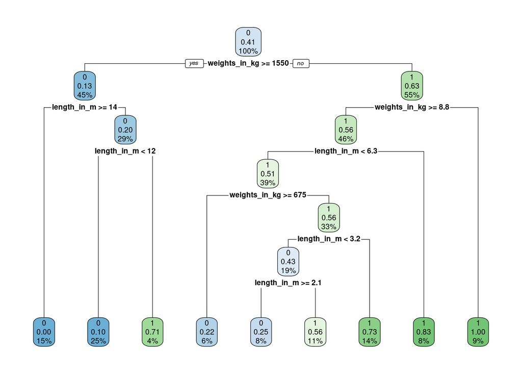

```r
set.seed(314)
library(rpart)

classTree<- rpart(carnivorous~length_in_m+weights_in_kg,
                  data = trainCaret,
                  method = "class")

### PLOT TREE
library(rpart.plot)
rpart.plot(classTree)
```

### STEP 14

● Step 14: (10 points) Prune your tree by finding the CP that minimizes the error. Re-plot your tree.

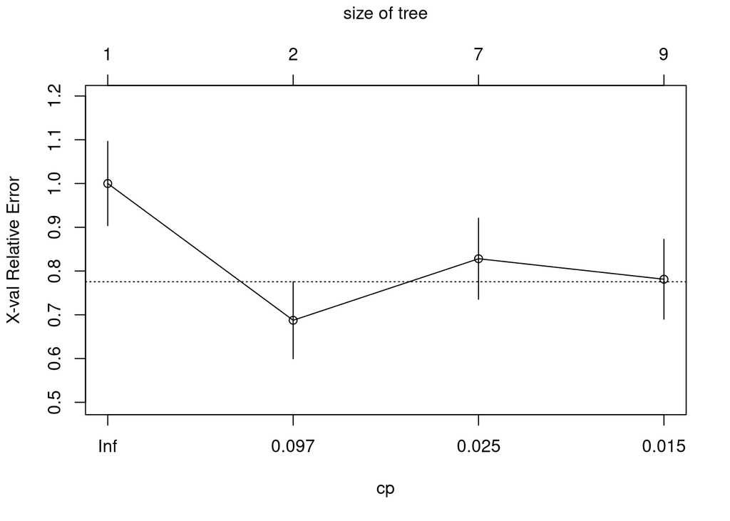

```r
library(rpart.plot)

### Plot CP
plotcp(classTree)
```

```r
printcp(classTree)
```

```
##
## Classification tree:
## rpart(formula = carnivorous ~ length_in_m + weights_in_kg, data = trainCaret,
##     method = "class")
##
## Variables actually used in tree construction:
## [1] length_in_m   weights_in_kg
##
## Root node error: 64/157 = 0.40764
##
## n= 157
##
##         CP nsplit rel error  xerror     xstd
## 1 0.359375      0   1.00000 1.00000 0.096206
## 2 0.026042      1   0.64062 0.68750 0.087930
## 3 0.023438      6   0.46875 0.82812 0.092582
## 4 0.010000      8   0.42188 0.78125 0.091211
```

```r
#don't want to over or under fit our trees

plot
```

```
## function (x, y, ...)
## UseMethod("plot")
## <bytecode: 0x55dffb67a130>
## <environment: namespace:base>
```

```r
## WHICH CP
minCP<-classTree$cptable[which.min(classTree$cptable[,"xerror"]),"CP"]
minCP
```

```
## [1] 0.02604167
```

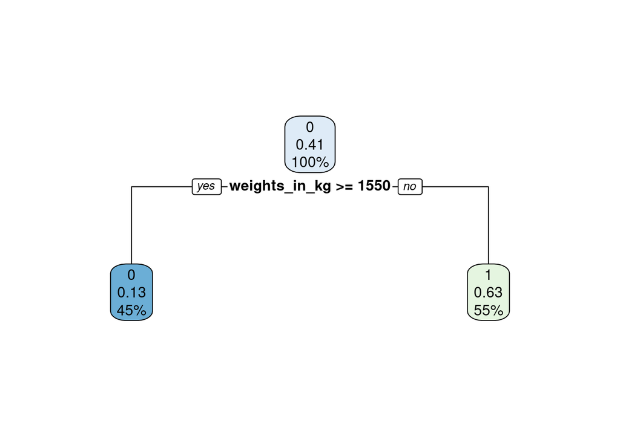

```r
prune_classTree <- prune(classTree, cp = minCP )
rpart.plot(prune_classTree )
```

### STEP 15

● Step 15: (10 points) Create a confusion matrix for your tree using the testing data. Calculate the correct rate.

```r
## DEFAULT TREE
### PREDICT
predTree1<-predict(classTree , testCaret, type="class")

### CONFUSION MATRIX
cmTree1<-table(testCaret$carnivorous, predTree1)
cmTree1
```

```
##    predTree1
##       0   1
##   0 123  45
##   1  27  89
```

```r
#### CORRECT RATE
mean(testCaret$carnivorous==predTree1)
```

```
## [1] 0.7464789
```

```r
## PRUNED TREE
### PREDICT
predTree2<-predict(prune_classTree , testCaret, type="class")

### CONFUSION MATRIX
cmTree2<-table(testCaret$herbivorous, predTree2)
cmTree2
```

```
##    predTree2
##       0   1
##   0  17  99
##   1 104  64
```

```r
#### CORRECT RATE
mean(testCaret$herbivorous==predTree2)
```

```
## [1] 0.2852113
```

```r
### CONFUSION MATRIX
#cmTree1<-table(predTree1, test27$y)
#cmTree1

## CORRECT RATE
#mean(predTree1==test27$y)
```

### STEP 16

● Step 16: (10 points) Fit your favorite tree aggregation technique using the caret package. State the parameters for the best model and show the variable importance plot.

```r
library(tidyverse)

### BAG

trainCaret$carnivorous<-as.factor(trainCaret$carnivorous)
set.seed(314)
#caretBag <- train(carnivorous~.,
                  #data=trainCaret,
                 # method="treebag",
                 # trControl=trainControl("cv", number=10),
                 # importance=TRUE)
##the caret method was throwing errors, so we used the other version
#predCaretBag <- caretBag%>%
  #predict(testCaret)

# CONFUSION MATRIX
#table(predCaretBag, testCaret$Two)

# CORRECT RATE
#mean(predCaretBag==testCaret$Two)

#library(vip)
#vip(caretBag)
```

```r
### BAGGING
library(caret)
library(ipred)  #includes the bagging function
library(rpart)

set.seed(252)
dinoBag <-bagging(carnivorous ~ .,
                   data = trainCaret%>%
                    select(-c(herbivorous)),
                   nbagg = 150,
                   coob = TRUE,
                   control = rpart.control(minsplit = 2, cp = 0))

##parameters for best model

##variance importance plot
library(vip)
#vip(dinoBag)
#vip package keeps throwing an error but we can assume there would be similarities between variable selection in bagging and the forward/backward selection
```

[output not shown]

### STEP 17

● Step 17: (10 points) Create a confusion matrix for your tree aggregation using the testing data. Calculate the correct rate.

```r
## PREDICT
preddinoo<-predict(dinoBag, testCaret, type="class")

## CONFUSION MATRIX
cmBag<-table(testCaret$carnivorous, preddinoo)
cmBag
```

```
##    preddinoo
##       0   1
##   0 152  16
##   1   5 111
```

```r
## CORRECT RATE
mean(testCaret$carnivorous==preddinoo)
```

```
## [1] 0.9260563
```

### STEP 18

Part V: Compare ● Step 18: (20 points) Create a table and compare your methods.

```r
##knn correct rate
mean(knn.best==testOut)
```

```
## [1] 0.8485915
```

```r
##logistic regression correct rate
mean(dino_pred2 == testFea$herbivorous)
```

```
## [1] 0
```

```r
##classification tree correct rate
mean(testCaret$carnivorous==predTree1)
```

```
## [1] 0.7464789
```

```r
##bagging correct rate
mean(testCaret$carnivorous==preddinoo)
```

```
## [1] 0.9260563
```

Pros and cons→ Trees can be very similar, Dominated by a few strong / moderately strong predictor, Bagged trees can be highly correlated, Does not lead to large reduction in variance when averaging